# Network_workshop

Chun Su

8/28/2019

```r
library(igraph)
library(tidyverse)
library(ggraph)
library(gridExtra)
```

# IGRAPH object

```r
make_graph(letters[1:10], directed = T)
```

```
## IGRAPH 365f78a DN-- 10 5 --
## + attr: name (v/c)
## + edges from 365f78a (vertex names):
## [1] a->b c->d e->f g->h i->j
```

# Graph Basics

## Create a graph

There are many ways to create graph from scratch. Here we are going to introduce three most popular ways to create graph using user-defined data.

### From edge list

The example below generates a directed graph from a list of vertex pair (edge)

```r
edge_list = data.frame(from = c(1, 2, 2, 3, 4), to = c(2, 3, 4, 2, 1))
edge_list
```

```
##   from to
## 1    1  2
## 2    2  3
## 3    2  4
## 4    3  2
## 5    4  1
```

```r
m = as.matrix(edge_list)
g = graph_from_edgelist(m,directed = TRUE)
g
```

```
## IGRAPH 88c2878 D--- 4 5 --
## + edges from 88c2878:
## [1] 1->2 2->3 2->4 3->2 4->1
```

If the edge is given in a single vector, the default make_graph will use the order of vector to make one-mode graph. It means that the first edge points from the first element to the second, the second edge from the third to the fourth, etc.

```r
g = make_graph(letters[1:10], directed = T)
g
```

```
## IGRAPH 00c6bfa DN-- 10 5 --
## + attr: name (v/c)
## + edges from 00c6bfa (vertex names):
## [1] a->b c->d e->f g->h i->j
```

### From adjacent matrix

The example below generates a undirected graph from a binary matrix, in which nodes are matrix colname and rowname.

```r
set.seed(123)
adj_matrix = matrix(sample(0:1, 100, replace=TRUE, prob=c(0.8,0.1)), nc=10)
colnames(adj_matrix)=letters[1:10]
rownames(adj_matrix)=letters[1:10]
adj_matrix
```

```
##   a b c d e f g h i j
## a 0 1 1 1 0 0 0 0 0 0
## b 0 0 0 1 0 0 0 0 0 0
## c 0 0 0 0 0 0 0 0 0 0
## d 0 0 1 0 0 0 0 0 0 0
## e 1 0 0 0 0 0 0 0 0 0
## f 0 1 0 0 0 0 0 0 0 0
## g 0 0 0 0 0 0 0 0 1 0
## h 1 0 0 0 0 0 0 0 1 0
## i 0 0 0 0 0 1 0 0 0 0
## j 0 1 0 0 0 0 0 0 0 0
```

```r
g = graph_from_adjacency_matrix(adj_matrix, mode = "undirected", weighted = T)
g
```

```
## IGRAPH b038d8b UNW- 10 12 --
## + attr: name (v/c), weight (e/n)
## + edges from b038d8b (vertex names):
##  [1] a--b a--c a--d a--e a--h b--d b--f b--j c--d f--i g--i h--i
```

There are other modes available with details at https://igraph.org/r/doc/graph_from_adjacency_matrix.html

### From data.frame

The graph generated from data.frame can add all attributes at once. Here is the example from official website. The attributes for nodes (actors) are `age` and `gender`, and edge (relationship) attributes include same.dept, friendship and advice

```r
actors <- data.frame(
  name=c("Alice", "Bob", "Cecil", "David","Esmeralda"),
  age=c(48,33,45,34,21),
  gender=c("F","M","F","M","F"))
relations <- data.frame(
  from=c("Bob", "Cecil", "Cecil", "David","David", "Esmeralda"),
  to=c("Alice", "Bob", "Alice", "Alice", "Bob", "Alice"),
  same.dept=c(FALSE,FALSE,TRUE,FALSE,FALSE,TRUE),
  friendship=c(4,5,5,2,1,1),
  advice=c(4,5,5,4,2,3)
  )
g <- graph_from_data_frame(relations, directed=TRUE, vertices=actors)
g
```

```
## IGRAPH 02e0700 DN-- 5 6 --
## + attr: name (v/c), age (v/n), gender (v/c), same.dept (e/l),
## | friendship (e/n), advice (e/n)
## + edges from 02e0700 (vertex names):
## [1] Bob      ->Alice Cecil    ->Bob   Cecil    ->Alice David    ->Alice
## [5] David    ->Bob   Esmeralda->Alice
```

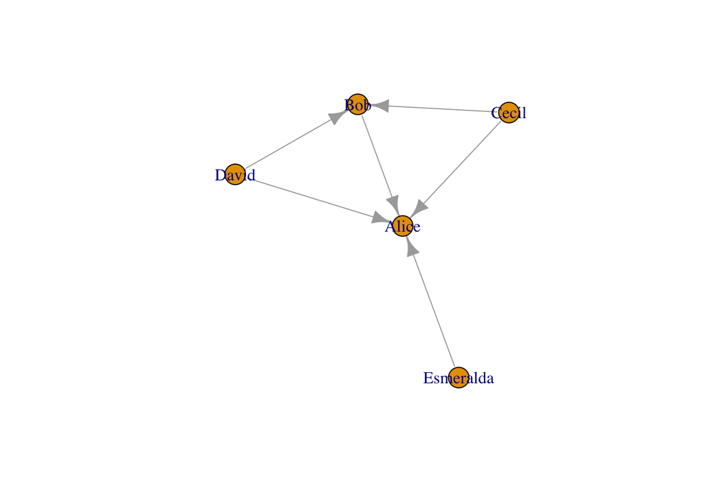

```r
plot(g)
```

### Create random graph

Random graph generation is useful when it comes to simulation.

```r
# sample 10 vertex, every possible edge is created with the same constant probability 0.3
set.seed(12)
sample_gnp(10, 0.3)
```

```
## IGRAPH b2b237b U--- 10 11 -- Erdos renyi (gnp) graph
## + attr: name (g/c), type (g/c), loops (g/l), p (g/n)
## + edges from b2b237b:
##  [1] 2-- 5 3-- 5 5-- 6 4-- 7 3-- 8 6-- 8 1-- 9 3-- 9 8-- 9 3--10 8--10
```

```r
# sample 10 vertex, create a 15-edge graph
set.seed(123)
sample_gnm(10, 15)
```

```
## IGRAPH c473636 U--- 10 15 -- Erdos renyi (gnm) graph
## + attr: name (g/c), type (g/c), loops (g/l), m (g/n)
## + edges from c473636:
##  [1] 1-- 2 1-- 4 2-- 4 3-- 4 5-- 6 2-- 7 3-- 7 5-- 7 2-- 8 3-- 8 6-- 8
## [12] 1-- 9 4-- 9 5--10 9--10
```

- Random scale free network, which means a network whose degree of nodes distribution follows a power law. `sample_pa` generates scale-free graphs according to the Barabasi-Albert model. We start with a single vertex and no edges in the first time step. Then we add one vertex in each time step and the new vertex initiates some edges to old vertices. The probability that an old vertex is chosen is given by $p(i) ~ k_i * power + zero.appeal$

```r
set.seed(123)
sample_pa(100, power = 2)
```

```
## IGRAPH d6bd628 D--- 100 99 -- Barabasi graph
## + attr: name (g/c), power (g/n), m (g/n), zero.appeal (g/n),
## | algorithm (g/c)
## + edges from d6bd628:
##  [1]  2-> 1  3-> 1  4-> 2  5-> 1  6-> 4  7-> 5  8-> 1  9-> 1 10-> 6 11-> 1
## [11] 12-> 1 13->10 14-> 1 15-> 1 16-> 1 17-> 1 18-> 5 19-> 1 20-> 1 21-> 1
## [21] 22->11 23-> 4 24-> 1 25-> 1 26->24 27-> 1 28-> 1 29-> 1 30-> 1 31-> 1
## [31] 32-> 1 33->14 34-> 1 35-> 1 36-> 1 37-> 1 38-> 1 39-> 1 40-> 1 41-> 1
## [41] 42-> 1 43-> 1 44-> 1 45-> 1 46-> 1 47-> 1 48-> 1 49-> 1 50-> 1 51-> 1
## [51] 52-> 1 53-> 1 54-> 1 55-> 1 56-> 1 57-> 1 58-> 1 59-> 1 60-> 1 61-> 1
## [61] 62-> 1 63-> 1 64-> 1 65-> 1 66-> 1 67-> 1 68-> 1 69-> 1 70-> 1 71-> 1
## + ... omitted several edges
```

## Retrieve vertex and edge from IGRAPH

Vertex and edge information can be retrieved from igraph use two ways.

- Use `igraph.vs` and `igraph.es“” object
- Convert to data.frame

```r
# use V() to obtain igraph.vs object
V(g)$name
```

```
## [1] "Alice"     "Bob"       "Cecil"     "David"     "Esmeralda"
```

```r
V(g)$age
```

```
## [1] 48 33 45 34 21
```

```r
V(g)$gender
```

```
## [1] "F" "M" "F" "M" "F"
```

```r
# use E() to get igraph.es object
```

`igraph.es` and `igraph.vs` object can be converted to classic vector of names by `as_ids()`.

```r
# vertices all attributes
igraph::as_data_frame(g, what = "vertices")
```

```
##                name age gender
## Alice         Alice  48      F
## Bob             Bob  33      M
## Cecil         Cecil  45      F
## David         David  34      M
## Esmeralda Esmeralda  21      F
```

```r
# edges all attributes
igraph::as_data_frame(g, what = "edges")
```

```
##        from    to same.dept friendship advice
## 1       Bob Alice     FALSE          4      4
## 2     Cecil   Bob     FALSE          5      5
## 3     Cecil Alice      TRUE          5      5
## 4     David Alice     FALSE          2      4
## 5     David   Bob     FALSE          1      2
## 6 Esmeralda Alice      TRUE          1      3
```

## Add/Delete vertex and edges

Vertices and edges can be added to existing graph by `add_()` or `+`. Please be aware that vertices of added new edges must be from known vertices already in the graph.

```r
# add vertices
g %>% add_vertices(2, name=c("Lisa","Zack")) # the first argument is number of vertex
```

```
## IGRAPH fda0d32 DN-- 7 6 --
## + attr: name (v/c), age (v/n), gender (v/c), same.dept (e/l),
## | friendship (e/n), advice (e/n)
## + edges from fda0d32 (vertex names):
## [1] Bob      ->Alice Cecil    ->Bob   Cecil    ->Alice David    ->Alice
## [5] David    ->Bob   Esmeralda->Alice
```

```r
g + vertices(c("Lisa","Zack"))
```

```
## IGRAPH ecb0d1e DN-- 7 6 --
## + attr: name (v/c), age (v/n), gender (v/c), same.dept (e/l),
## | friendship (e/n), advice (e/n)
## + edges from ecb0d1e (vertex names):
## [1] Bob      ->Alice Cecil    ->Bob   Cecil    ->Alice David    ->Alice
## [5] David    ->Bob   Esmeralda->Alice
```

```r
# add connected edges (even number of vertices). The vertices must be from known vertices already in the graph
g %>% add_edges(c("Alice","Bob"))
```

```
## IGRAPH 55c3ac1 DN-- 5 7 --
## + attr: name (v/c), age (v/n), gender (v/c), same.dept (e/l),
## | friendship (e/n), advice (e/n)
## + edges from 55c3ac1 (vertex names):
## [1] Bob      ->Alice Cecil    ->Bob   Cecil    ->Alice David    ->Alice
## [5] David    ->Bob   Esmeralda->Alice Alice    ->Bob
```

```r
g + edge(c("Alice","Bob"))
```

```
## IGRAPH b01e05a DN-- 5 7 --
## + attr: name (v/c), age (v/n), gender (v/c), same.dept (e/l),
## | friendship (e/n), advice (e/n)
## + edges from b01e05a (vertex names):
## [1] Bob      ->Alice Cecil    ->Bob   Cecil    ->Alice David    ->Alice
## [5] David    ->Bob   Esmeralda->Alice Alice    ->Bob
```

```r
# add paths. The vertices must be from known vertices already in the graph
g + path("Alice","Bob","Cecil")
```

```
## IGRAPH 35b8ad3 DN-- 5 8 --
## + attr: name (v/c), age (v/n), gender (v/c), same.dept (e/l),
## | friendship (e/n), advice (e/n)
## + edges from 35b8ad3 (vertex names):
## [1] Bob      ->Alice Cecil    ->Bob   Cecil    ->Alice David    ->Alice
## [5] David    ->Bob   Esmeralda->Alice Alice    ->Bob   Bob      ->Cecil
```

```r
# If a new vertex needs to be added to current graph, using add graph method instead
g + make_graph(c("Alice","Bob","Bob","Melisa"))
```

```
## IGRAPH be8300f DN-- 6 8 --
## + attr: age (v/n), gender (v/c), name (v/c), same.dept (e/l),
## | friendship (e/n), advice (e/n)
## + edges from be8300f (vertex names):
## [1] Esmeralda->Alice  David    ->Bob    David    ->Alice  Cecil    ->Bob
## [5] Cecil    ->Alice  Bob      ->Melisa Bob      ->Alice  Alice    ->Bob
```

Delete can be done in a similar way.

```r
### remove the vertices whose age is younger than 30
vertex_df = g %>% igraph::as_data_frame(what="vertices") %>% tbl_df %>% mutate(index=row_number()) %>% filter(age < 30)
# remove vertices by index number
g %>% delete_vertices(vertex_df$index)
```

```
## IGRAPH daa97c3 DN-- 4 5 --
## + attr: name (v/c), age (v/n), gender (v/c), same.dept (e/l),
## | friendship (e/n), advice (e/n)
## + edges from daa97c3 (vertex names):
## [1] Bob  ->Alice Cecil->Bob   Cecil->Alice David->Alice David->Bob
```

```r
# remove vertice by name
g %>% delete_vertices(vertex_df$name)
```

```
## IGRAPH 4b7ecab DN-- 4 5 --
## + attr: name (v/c), age (v/n), gender (v/c), same.dept (e/l),
## | friendship (e/n), advice (e/n)
## + edges from 4b7ecab (vertex names):
## [1] Bob  ->Alice Cecil->Bob   Cecil->Alice David->Alice David->Bob
```

```r
### remove the edges with friendship <= 1
edge_df = g %>% igraph::as_data_frame(what="edges") %>% tbl_df %>% mutate(index=row_number()) %>% mutate(name=paste(from,to,sep="|")) %>% filter(friendship <= 1)
# remove vertice by index
g %>% delete_edges(edge_df$index)
```

```
## IGRAPH 79d614e DN-- 5 4 --
## + attr: name (v/c), age (v/n), gender (v/c), same.dept (e/l),
## | friendship (e/n), advice (e/n)
## + edges from 79d614e (vertex names):
## [1] Bob  ->Alice Cecil->Bob   Cecil->Alice David->Alice
```

```r
# remove vertice by name
g %>% delete_edges(edge_df$name)
```

```
## IGRAPH 21b381d DN-- 5 4 --
## + attr: name (v/c), age (v/n), gender (v/c), same.dept (e/l),
## | friendship (e/n), advice (e/n)
## + edges from 21b381d (vertex names):
## [1] Bob  ->Alice Cecil->Bob   Cecil->Alice David->Alice
```

The attributes of vertices and edges can be added or deleted to existing graph by `set_vertex_attr()`/`set_edge_attr()` or `delete_vertex_attr()`/`delete_edge_attr()`.

```r
# add a new attr "relationship" for people in the same dept
edge_df = g %>% igraph::as_data_frame(what="edges") %>%
  mutate(relationship=ifelse(same.dept,"collegue",NA))

g %>% set_edge_attr("relationship", which(!is.na(edge_df$relationship)), edge_df$relationship[!is.na(edge_df$relationship)])
```

```
## IGRAPH 02e0700 DN-- 5 6 --
## + attr: name (v/c), age (v/n), gender (v/c), same.dept (e/l),
## | friendship (e/n), advice (e/n), relationship (e/c)
## + edges from 02e0700 (vertex names):
## [1] Bob      ->Alice Cecil    ->Bob   Cecil    ->Alice David    ->Alice
## [5] David    ->Bob   Esmeralda->Alice
```

## Merge graph

Graphs union/intersection is to merge two or more graphs into one graph using the shared the vertices.

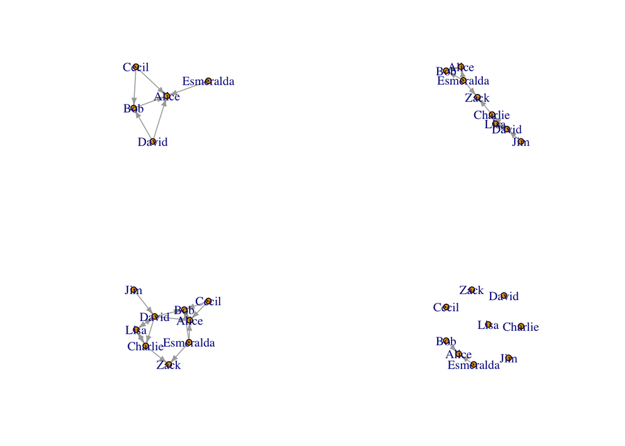

```r
g2 = graph_from_literal("David"-+"Charlie"+-+"Lisa",
                        "Lisa"+-+"David"+-"Jim",
                        "Zack"+-"Esmeralda"-+"Bob",
                        "Zack"+-"Charlie",
                        "Lisa"+-"Lisa",
                        "Bob"-+"Alice"+-"Esmeralda"
                        )

#### union graph
g3 = igraph::union(g,g2)
#### graph intersection
g4 = igraph::intersection(g,g2)

par(mfrow=c(2,2))
plot(g, edge.arrow.size=.4)
plot(g2, edge.arrow.size=.4)
plot(g3, edge.arrow.size=.4)
plot(g4, edge.arrow.size=.4)
```

## Induce subgraph

The subgraph can be induced by either vertex or edge names/index. The edge names are in the form `from|to`.

```r
# induce a subgraph using a list of vertices
igraph::induced_subgraph(g, v=c("Alice","Bob","Cecil"))
```

```
## IGRAPH 0dd4842 DN-- 3 3 --
## + attr: name (v/c), age (v/n), gender (v/c), same.dept (e/l),
## | friendship (e/n), advice (e/n)
## + edges from 0dd4842 (vertex names):
## [1] Bob  ->Alice Cecil->Bob   Cecil->Alice
```

```r
# induce a subgraph using edges
subgraph.edges(g, c("Bob|Alice","Cecil|Bob","Cecil|Alice"), delete.vertices = TRUE)
```

```
## IGRAPH 18fd411 DN-- 3 3 --
## + attr: name (v/c), age (v/n), gender (v/c), same.dept (e/l),
## | friendship (e/n), advice (e/n)
## + edges from 18fd411 (vertex names):
## [1] Bob  ->Alice Cecil->Bob   Cecil->Alice
```

```r
# induce a subgraph using edges attribute (friendship score stronger than 3)
e1 = E(g)[E(g)$friendship > 3]
igraph::subgraph.edges(g, e1, delete.vertices = TRUE)
```

```
## IGRAPH 913598b DN-- 3 3 --
## + attr: name (v/c), age (v/n), gender (v/c), same.dept (e/l),
## | friendship (e/n), advice (e/n)
## + edges from 913598b (vertex names):
## [1] Bob  ->Alice Cecil->Bob   Cecil->Alice
```

# Graph Advance

In this session, we are going to use a new undirected graph (gr) generated by `sample_gnp()`.

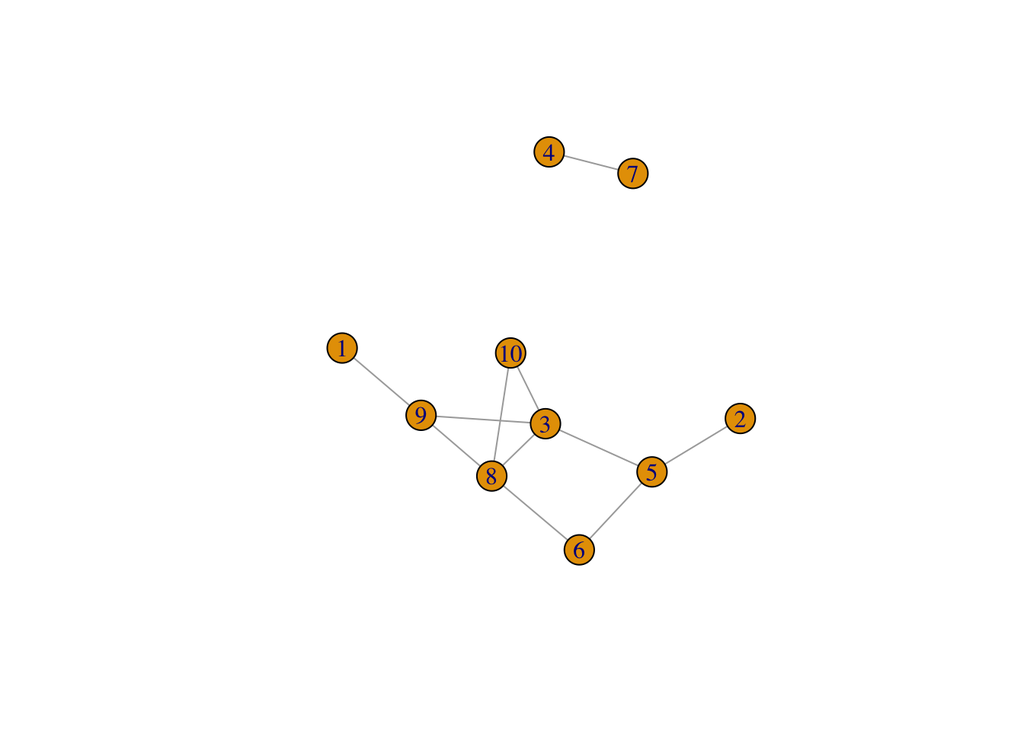

```r
# generate random graph
set.seed(12)
gr <- sample_gnp(10, 0.3)
plot(gr)
```

## Graph measurement

### Degree and strength

**Degree** is a very important graph measurement. For a given node(s) to get its degree, we use `degree`. Be aware that, for directed graph, the node degree can be in-degree (the edge number pointing to the node) and out-degree (the edge number pointing from node). We can also summarise the all degree by using `degree_distribution`.

```r
# get degree for each node
degree(gr, v=1:10)
```

```
##  [1] 1 1 4 1 3 2 1 4 3 2
```

```r
# degree distribution
degree_distribution(g) # probability for degree 0,1,2,3,4
```

```
## [1] 0.0 0.2 0.4 0.2 0.2
```

`strength` is weigthed version of `degree`, by summing up the edge weights of the adjacent edges for each vertex.

```r
# add random weight attribute
set.seed(12)
gr2 = gr %>% set_edge_attr(
  "weight",index=E(gr),
  value=sample(seq(0,1,0.05),size=length(E(gr)))
)
# calculate strength
strength(gr2, weights = E(gr)$weight)
```

```
##  [1] 0.95 0.05 1.90 0.20 1.70 0.85 0.20 1.75 2.10 1.50
```

```r
# [1] 0.50 1.00 2.25 0.85 1.80 0.25 0.85 1.55 1.20 1.55
```

### Order and path

Order measures measures the edge number from one node to another. In `igraph` package, we use `distances` function to get order between two vertices. For directed graph, `in` mode only follow the paths toward the first node, while `out` mode goes away from the first node. If no connection can be made, `Inf` will be return.

```r
# count all edges from 1 to 10, regardless of direction
distances(gr, v=1, to=10, mode="all", weights = NA)
```

```
##      [,1]
## [1,]    3
```

```r
# pairwise distance table
distances(gr, mode="all")
```

```
##       [,1] [,2] [,3] [,4] [,5] [,6] [,7] [,8] [,9] [,10]
##  [1,]    0    4    2  Inf    3    3  Inf    2    1     3
##  [2,]    4    0    2  Inf    1    2  Inf    3    3     3
##  [3,]    2    2    0  Inf    1    2  Inf    1    1     1
##  [4,]  Inf  Inf  Inf    0  Inf  Inf    1  Inf  Inf   Inf
##  [5,]    3    1    1  Inf    0    1  Inf    2    2     2
##  [6,]    3    2    2  Inf    1    0  Inf    1    2     2
##  [7,]  Inf  Inf  Inf    1  Inf  Inf    0  Inf  Inf   Inf
##  [8,]    2    3    1  Inf    2    1  Inf    0    1     1
##  [9,]    1    3    1  Inf    2    2  Inf    1    0     2
## [10,]    3    3    1  Inf    2    2  Inf    1    2     0
```

To get detail route from one node to another, we use `path`.

```r
# shortest path to connect
all_shortest_paths(gr, 1,10)$res
```

```
## [[1]]
## + 4/10 vertices, from c6e02ad:
## [1]  1  9  8 10
##
## [[2]]
## + 4/10 vertices, from c6e02ad:
## [1]  1  9  3 10
```

```r
# all path to connect
all_simple_paths(gr, 1,10)
```

```
## [[1]]
## + 7/10 vertices, from c6e02ad:
## [1]  1  9  3  5  6  8 10
##
## [[2]]
## + 5/10 vertices, from c6e02ad:
## [1]  1  9  3  8 10
##
## [[3]]
## + 4/10 vertices, from c6e02ad:
## [1]  1  9  3 10
##
## [[4]]
## + 5/10 vertices, from c6e02ad:
## [1]  1  9  8  3 10
##
## [[5]]
## + 7/10 vertices, from c6e02ad:
## [1]  1  9  8  6  5  3 10
##
## [[6]]
## + 4/10 vertices, from c6e02ad:
## [1]  1  9  8 10
```

### Transitivity

**Transitivity** measures the probability that the adjacent vertices of a vertex are connected. This is also called the **clustering coefficient**, a proxy to determine how well connected the graph is. This property is very important in social networks, and to a lesser degree in other networks

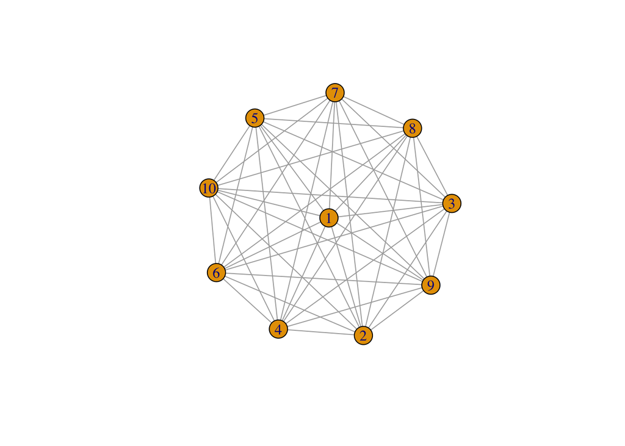

```r
# two extreme classes -- full graph and ring graph
g1 = make_full_graph(10)
plot(g1)
```

```r
transitivity(g1)
```

```
## [1] 1
```

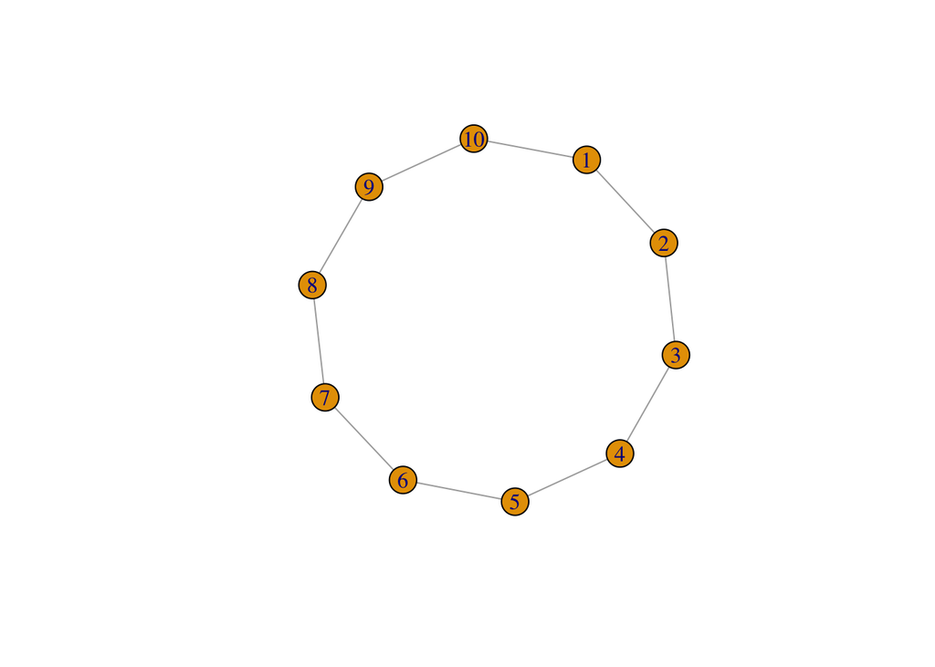

```r
g2 = make_ring(10)
plot(g2)
```

```r
transitivity(g2)
```

```
## [1] 0
```

There are multiple different types of transivity can be calculated (weighted or unweigthed). Also, the transivity can be calcualted locally for a subgraph by specifying vertex ids. See details by `help("transitivity")`

### Centrality

Centrality indices identify the most important vertices within a graph. In other words, the “hub” of network. However, this “importance” can be conceived in two ways:

- in relation to a type of flow or transfer across the network.
- involvement in the cohesiveness of the network

The simplest of centrality indicator is degree centrality (`centr_degree`), aka, a node is important if it has many neighbors. Besides degree centrality, there are

- closeness centrality (`centr_clo`) - a node is important if it takes the shortest mean distance from a vertex to other vertices
- betweenness centrality (`centr_betw`) - a node is important if extent to which a vertex lies on paths between other vertices are high.
- eigenvector centrality (`centr_eigen`) - a node is important if it is linked to by other important nodes.

```r
centr_degree(g, mode="all")
```

```
## $res
## [1] 4 3 2 2 1
##
## $centralization
## [1] 0.25
##
## $theoretical_max
## [1] 32
```

```r
centr_clo(g, mode = "all")
```

```
## $res
## [1] 1.0000000 0.8000000 0.6666667 0.6666667 0.5714286
##
## $centralization
## [1] 0.7555556
##
## $theoretical_max
## [1] 1.714286
```

```r
centr_betw(g, directed = FALSE)
```

```
## $res
## [1] 3.5 0.5 0.0 0.0 0.0
##
## $centralization
## [1] 0.5625
##
## $theoretical_max
## [1] 24
```

```r
centr_eigen(g,directed = FALSE)
```

[output not shown]

[output cut: 18 more lines]

```
## $options$numop
## [1] 18
##
## $options$numopb
## [1] 0
##
## $options$numreo
## [1] 11
##
##
## $centralization
## [1] 0.438152
##
## $theoretical_max
## [1] 3
```

Many other centrality indicators refer to [wiki](https://en.wikipedia.org/wiki/Centrality)